# SOLAR models applied to GAIT1 data set

Helena Brunel, Andrey Ziyatdinov

2016-01-11

```r
library(gait)
library(plyr)
```

# 1 About

We selected 3 specific examples where we could compare the results obtained with the ‘solarius’ package with those previously obtained and published in Sabater2012 and Souto2014. The 3 selected phenotypes were the FXI levels in blood, the BMI and the Thrombosis affection.

# 2 Load packages

```r
library(solarius)
library(gait)
```

# 3 Load GAIT1 data

We first load our data and properly transform the phenotypes under study.

```r
pdat  <- gait1.phen()
pdat <- mutate(pdat,
  tr_FXI = FXI_T * 5.1,
  ln_bmi = log(bmi),
  tr_bmi = 6.1 * ln_bmi)

gait1.snpfiles <- gait1.snpfiles()

mibddir <- gait1.mibddir()
```

```r
cores <- 64
```

# 4 FXI

We first applied the main models of association and linkage of the package to the FXI levels in blood. The FXI phenotype has already been studied in the same dataset as described in Sabater-Lleal et al. (2012). This example aims to illustrate the proper behaviour of the solarius package by replicating these former results.

The polygenic model that estimates the heritability of the FXI levels in blood is described by M.F11.

```r
# trait previously transformed, only significant covariates
M.F11 <- solarPolygenic(tr_FXI ~ AGE, pdat, covtest=T)
M.F11
```

```
##
## Call: solarPolygenic(formula = tr_FXI ~ AGE, data = pdat, covtest = T)
##
## File polygenic.out:
##  Pedigree:    dat.ped
##  Phenotypes:  dat.phe
##  Trait:       tr_FXI                Individuals:  343
##
##           H2r is 0.3661086  p = 0.0000264  (Significant)
##         H2r Std. Error:  0.1041961
##
##            C2 is 0.1708059  p = 0.0119484  (Significant)
##          C2 Std. Error:  0.0816026
##
##                                       AGE  p = 2.2310194e-08  (Significant)
##
##  76 pedigrees merged into 68 pedigree-household groups
##
##  Proportion of Variance Due to All Final Covariates Is
##                0.0694126
##
##  Loglikelihoods and chi's are in tr_FXI/polygenic.logs.out
##  Best model is named housepoly and null0
##  Final models are named housepoly, house, poly, spor, nocovar
##  Initial sporadic and polygenic models are s0 and p0
##  Initial household and household polygenic models are h0 and hp0
##  Constrained covariate models are named no<covariate name>
##
##  Residual Kurtosis is 0.1813, within normal range
```

The model of association is described by A.F11

```r
A.F11 <- solarAssoc(tr_FXI ~ AGE, pdat,
  genocov.files = gait1.snpfiles$genocov.files,
  snplists.files = gait1.snpfiles$snplists.files,
  snpmap.files = gait1.snpfiles$snpmap.files,
  cores = cores)
```

```r
summary(A.F11)
```

```
##
## Call: solarAssoc(formula = newTrait ~ AGE, data = pdat, genocov.files = gait1.snpfiles$genocov.files,
##     snplists.files = gait1.snpfiles$snplists.files, snpmap.files = gait1.snpfiles$snpmap.files,
##     cores = cores, household = T)
##
## Association model
##  * Number of SNPs: 307984
##  * Input format: genocov.files
##  * Number of significal SNPs: 3 (Bonferroni correction with alpha 0.05)
##          SNP NAv      chi            pSNP      bSNP   bSNPse   Varexp
## 1:  rs710446 335 35.23666 0.0000000029198 -0.496124 0.083578 0.123276
## 2: rs4241824 335 33.93267 0.0000000057053 -0.485302 0.083311 0.095803
## 3: rs4253399 335 31.49100 0.0000000200370 -0.482461 0.085974 0.081138
##     est_maf  est_mac dosage_sd       pos chr
## 1: 0.547689 366.9516  0.689128 187942621   3
## 2: 0.470977 315.5543  0.710904 187428781   4
## 3: 0.585840 392.5128  0.714496 187425088   4
```

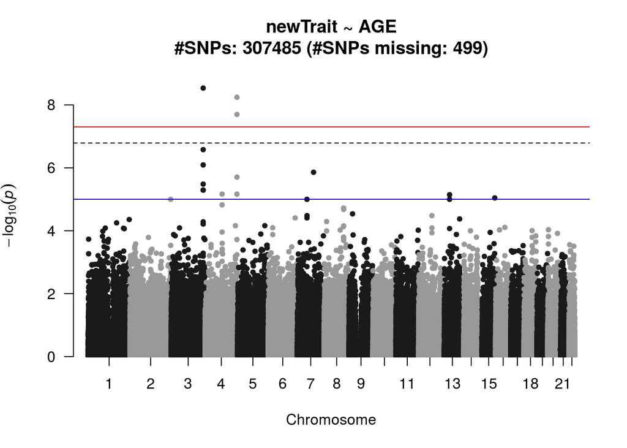

```r
plot(A.F11)
```

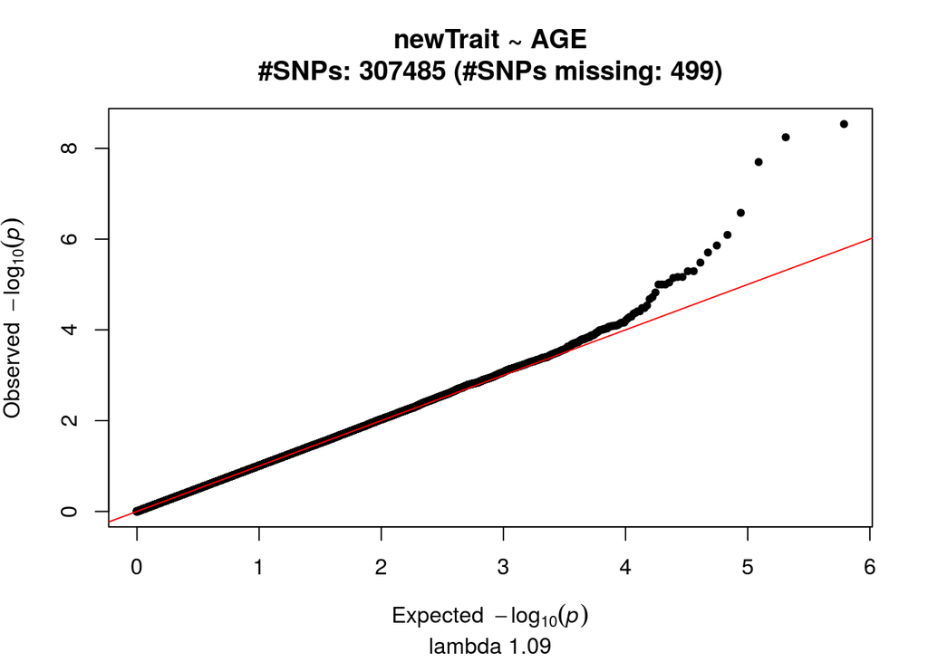

```r
plot(A.F11, "qq")
```

```r
L.F11 <- solarMultipoint(tr_FXI ~ AGE, data = pdat,
  mibdir = mibdir,
  chr = 1:22, interval = 5,
  cores = cores, verbose = 1)
```

The linkage model is described by L.F11.

```r
summary(L.F11)
```

```
##
## Call: solarMultipoint(formula = tr_FXI ~ AGE, data = dat, mibddir = mibddir,
##     chr = 1:22, interval = 5, cores = cores, verbose = 1)
##
## Multipoint model
##  * Number of used markers: 921
##  * Number of passes: 1
##  * Maximum LOD score: 1.79
##   -- chr: 2
##   -- position: 65 cM
```

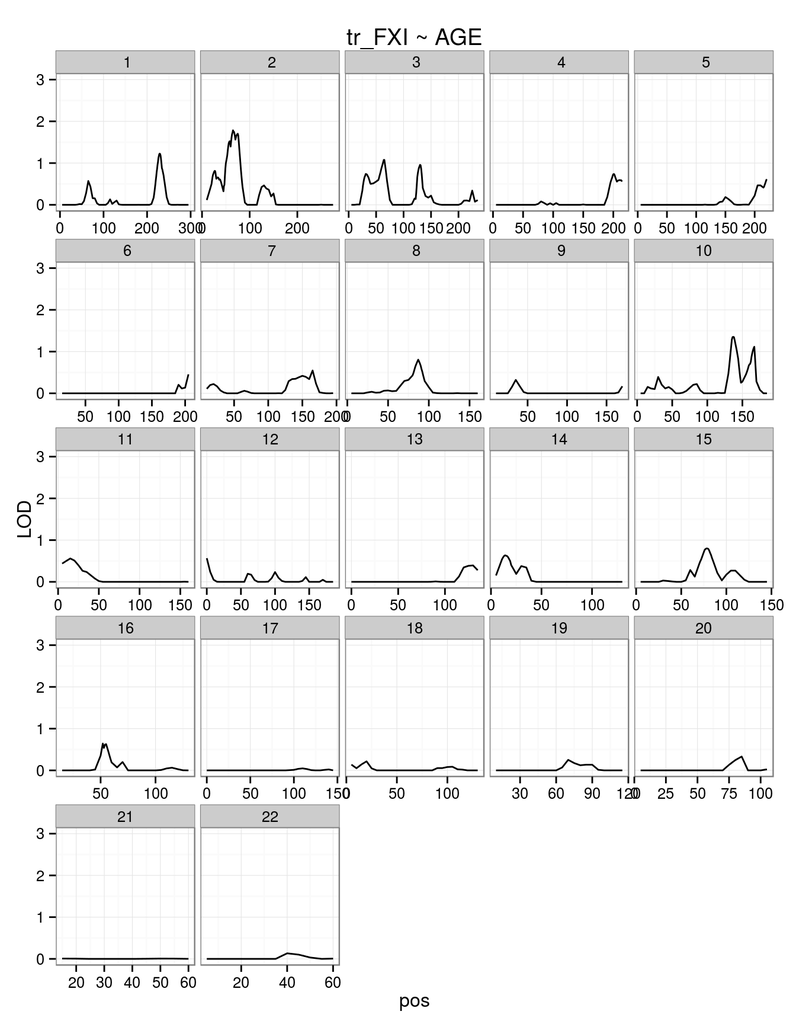

```r
plot(L.F11)
```

We observe that no significant loci are found using the linkage model.

# 5 BMI

The second example consists on applying the same models to the Body Mass Index (BMI). In this case, we also have a reference publication to compare with (J. Souto et al. (2014)). In contrast with the previous example, in J. Souto et al. (2014), only linkage signals showed significant peaks for the BMI phenotype.

M.bmi estimates the BMI heritability

```r
# trait previously transformed, only significant covariates
M.bmi <- solarPolygenic(tr_bmi ~ AGE, pdat, covtest = TRUE)
M.bmi
```

```
##
## Call: solarPolygenic(formula = tr_bmi ~ AGE, data = pdat, covtest = TRUE)
##
## File polygenic.out:
##  Pedigree:    dat.ped
##  Phenotypes:  dat.phe
##  Trait:       tr_bmi                Individuals:  398
##
##           H2r is 0.2724851  p = 0.0000835  (Significant)
##         H2r Std. Error:  0.0875573
##
##            C2 is 0.1377360  p = 0.0120571  (Significant)
##          C2 Std. Error:  0.0662269
##
##                                       AGE  p = 2.5499507e-32  (Significant)
##
##  76 pedigrees merged into 68 pedigree-household groups
##
##  Proportion of Variance Due to All Final Covariates Is
##                0.2699754
##
##  Loglikelihoods and chi's are in tr_bmi/polygenic.logs.out
##  Best model is named housepoly and null0
##  Final models are named housepoly, house, poly, spor, nocovar
##  Initial sporadic and polygenic models are s0 and p0
##  Initial household and household polygenic models are h0 and hp0
##  Constrained covariate models are named no<covariate name>
##
##  Residual Kurtosis is 0.7106, within normal range
```

The model of asscociation between GAIT SNPs and the BMI phenotype is described by A.bmi.

```r
A.bmi <- solarAssoc(tr_bmi ~ AGE, pdat,
  genocov.files = gait1.snpfiles$genocov.files,
  snplists.files = gait1.snpfiles$snplists.files,
  snpmap.files = gait1.snpfiles$snpmap.files,
  cores = cores)
```

```r
summary(A.bmi)
```

```
##
## Call: solarAssoc(formula = tr_bmi ~ AGE, data = pdat, genocov.files = gait1.snpfiles$genocov.files,
##     snplists.files = gait1.snpfiles$snplists.files, snpmap.files = gait1.snpfiles$snpmap.files,
##     cores = cores)
##
## Association model
##  * Number of SNPs: 307984
##  * Input format: genocov.files
##  * Number of significal SNPs: 0 (Bonferroni correction with alpha 0.05)
```

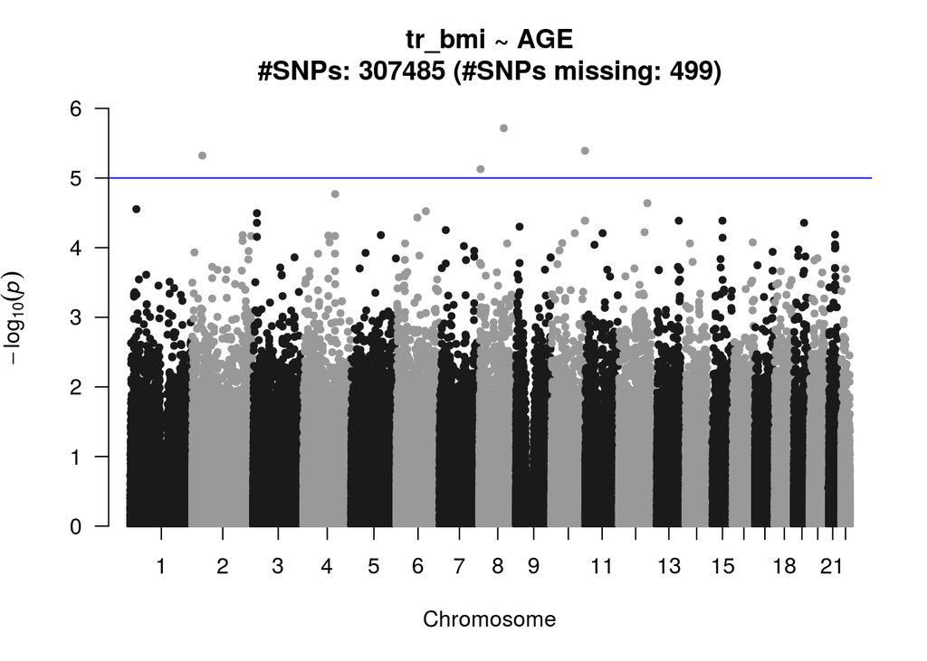

```r
plot(A.bmi)
```

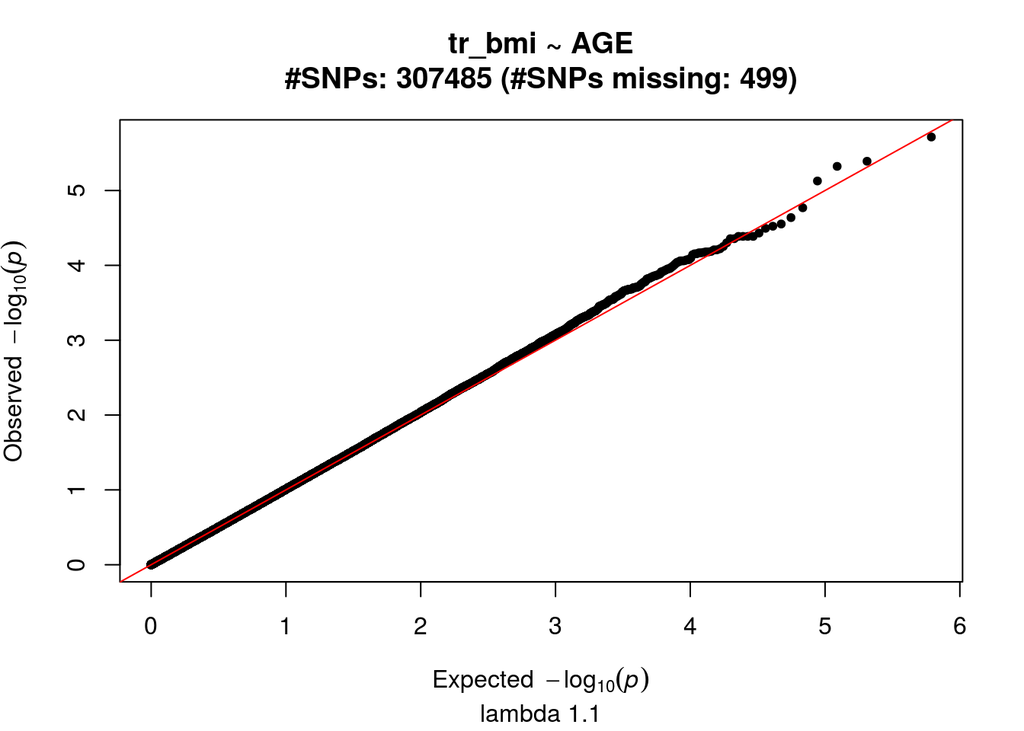

```r
plot(A.bmi, "qq")
```

As expected we do not detect any significantly associated SNPs.

The model of linkage for the BMI phenotype is described by L.bmi.

```r
L.bmi <- solarMultipoint(formula = tr_bmi ~ AGE, data = dat,
  mibddir = mibddir,
  chr = 1:22, interval = 5, cores = cores, verbose = 1)
```

```r
summary(L.bmi)
```

```
##
## Call: solarMultipoint(formula = tr_bmi ~ AGE, data = dat, mibddir = mibddir,
##     chr = 1:22, interval = 5, cores = cores, verbose = 1)
##
## Multipoint model
##  * Number of used markers: 989
##  * Number of passes: 1
##  * Maximum LOD score: 3.57
##   -- chr: 13
##   -- position: 138 cM
```

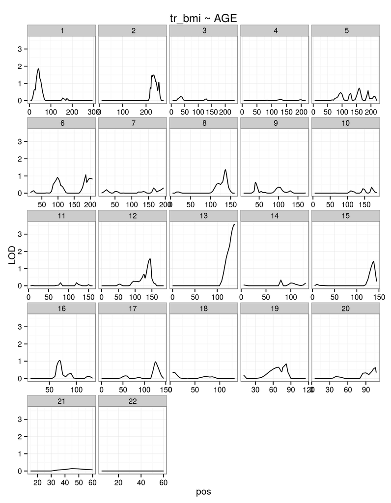

```r
plot(L.bmi)
```

We obtain a significant peak of linkage at chromosome 13. This replicates the result reported in J. Souto et al. (2014) with a linkage multiploint analysis of the bmi in the GAIT1.

## 5.1 Two-pass linkage

In order to evaluate the impact of this finding in related loci, we applied a second univariate linkage analysis, conditioned on the linkage signal obtained at 13q34 locus, as in J. Souto et al. (2014).

```r
# parallel computation of multi-pass linkage is not implemented in `solarius` yet
L.bmi.twopass <- solarMultipoint(tr_bmi ~ AGE, pdat,
  mibddir = mibddir,
  interval = 5, multipoint.options = "3")
```

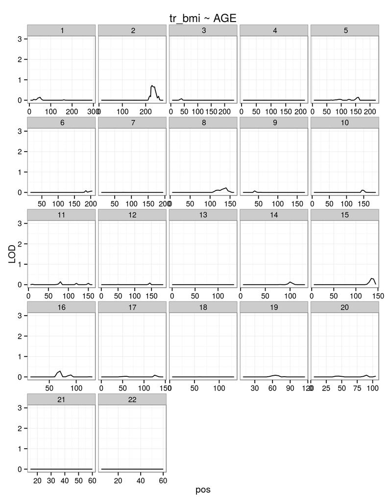

```r
plot(L.bmi.twopass, pass = 2)
```

We observe that in this second linkage analysis, conditioned on the former significant LOD score, the signal on chromosome 13q34 dropped dramatically to 0, as expected.

# 6 Throm

In order to illustrate the behaviour of the described models with dichotomous phenotypes, we finally applied them to the Thrombosis affection status.

The heritability of Thrombosis is estimated with M.aff.

```r
M.aff <- solarPolygenic(aff ~ AGE, pdat, covtest = TRUE)
M.aff
```

```
##
## Call: solarPolygenic(formula = aff ~ AGE, data = pdat, covtest = TRUE)
##
## File polygenic.out:
##  Pedigree:    dat.ped
##  Phenotypes:  dat.phe
##  Trait:       aff                   Individuals:  401
##
##           H2r is 0.5853242  p = 0.0035257  (Significant)
##         H2r Std. Error:  0.2484225
##
##            C2 is 0.1003393  p = 0.2433638  (Not Significant)
##          C2 Std. Error:  0.1620715      (C2 retained because nonzero)
##
##                                       AGE  p = 7.2299817e-14  (Significant)
##
##  76 pedigrees merged into 68 pedigree-household groups
##
##  Kullback-Leibler R-squared is 0.1857369
##
##  Loglikelihoods and chi's are in aff/polygenic.logs.out
##  Best model is named housepoly and null0
##  Final models are named housepoly, house, poly, spor, nocovar
##  Initial sporadic and polygenic models are s0 and p0
##  Initial household and household polygenic models are h0 and hp0
##  Constrained covariate models are named no<covariate name>
```

The model of association is described by A.aff.

```r
A.aff <- solarAssoc(aff ~ AGE, pdat,
  genocov.files = gait1.snpfiles$genocov.files,
  snplists.files = gait1.snpfiles$snplists.files,
  snpmap.files = gait1.snpfiles$snpmap.files,
  cores = cores)
```

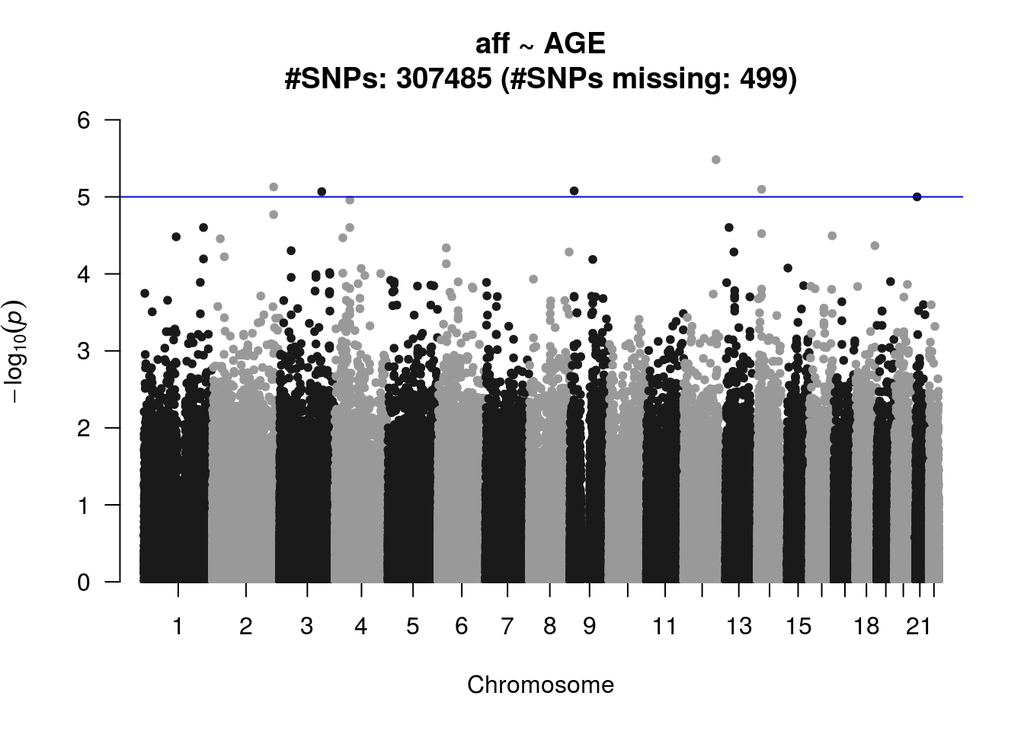

```r
plot(A.aff)
```

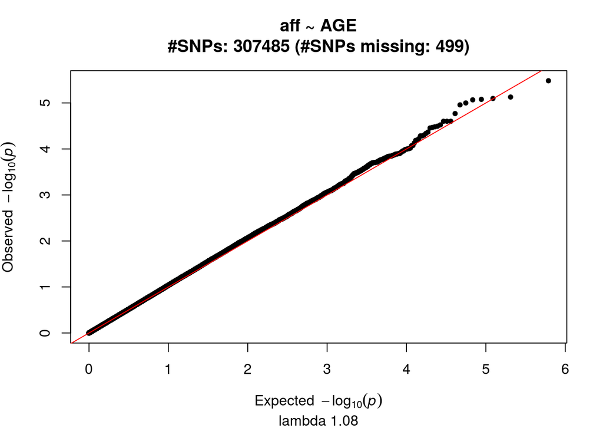

```r
plot(A.aff, "qq")
```

The model of linkage is described by L.aff.

```r
L.aff <- solarMultipoint(aff ~ AGE, data = dat,
  mibdir = mibdir,
  chr = 1:22, interval = 5,
  cores = cores, verbose = 1)
```

```r
summary(L.aff)
```

```
##
## Call: solarMultipoint(formula = aff ~ AGE, data = dat, mibddir = mibddir,
##     chr = 1:22, interval = 5, cores = cores, verbose = 1)
##
## Multipoint model
##  * Number of used markers: 896
##  * Number of passes: 1
##  * Maximum LOD score: 1.24
##   -- chr: 5
##   -- position: 174 cM
```

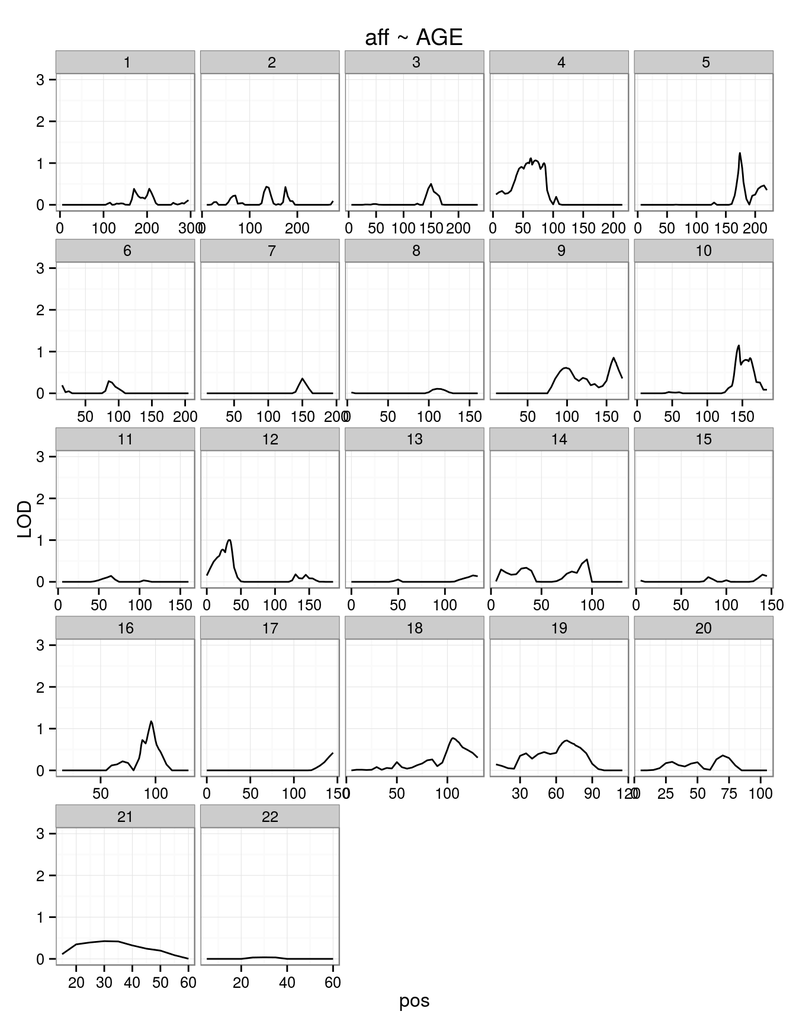

```r
plot(L.aff)
```

We observe that no significant findings are obtained neither in association nor in linkage analyses.

# 7 Bivariate analysis of BMI and Throm

We applied the bivariate linkage analysis with BMI and thrombosis affection, under the hypothesis of pleiotropy between BMI and liability to thrombosis.

```r
L.aff.bmi <- solarMultipoint(aff + bmi ~ AGE, pdat,
  mibddir = mibddir,
  chr = 1:22, interval = 5,
  cores = cores, verbose = 1)
```

```r
summary(L.aff.bmi)
```

```
##
## Call: solarMultipoint(formula = aff + bmi ~ AGE, data = dat, mibddir = mibddir,
##     chr = 1:22, interval = 5, cores = cores, verbose = 1)
##
## Multipoint model
##  * Number of used markers: 971
##  * Number of passes: 1
##  * Maximum LOD score: 3.56
##   -- chr: 13
##   -- position: 138 cM
```

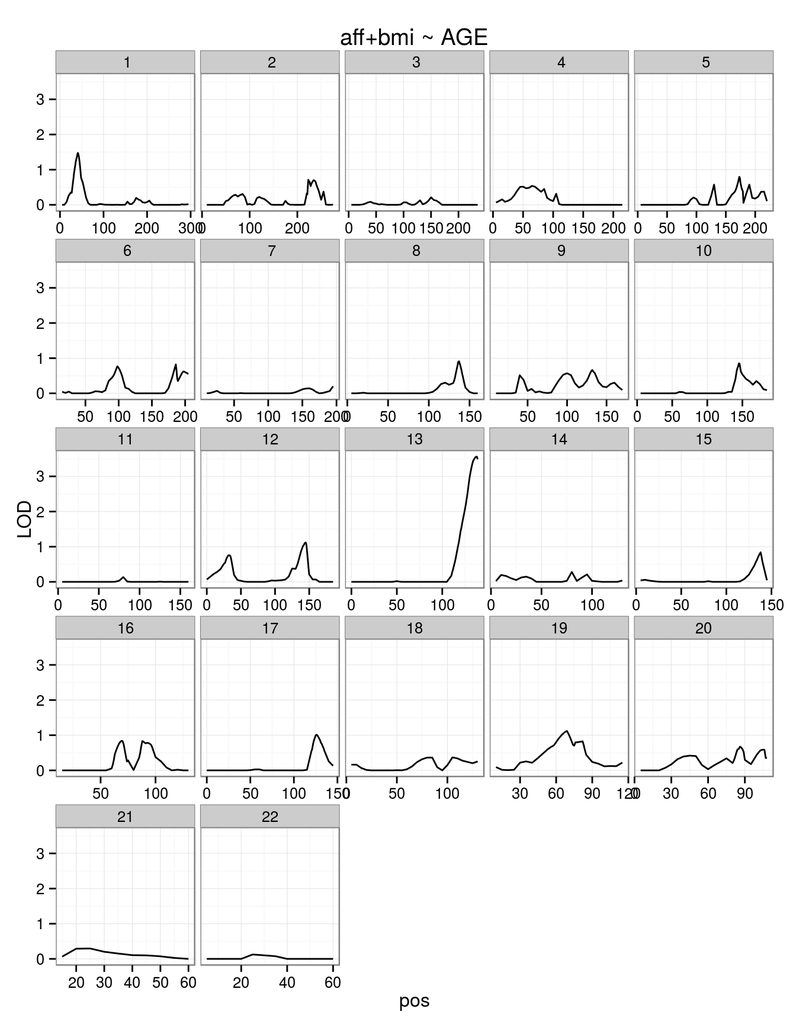

```r
plot(L.aff.bmi)
```

We observe, again, a significant peak of linkage at the 13q34 locus. This supports the hyposthesis proposed in J. Souto et al. (2014) of combined linkage between that region and BMI/thrombosis risk.

# 8 License

This document is licensed under the Creative Commons Attribution 4.0 International Public License.

References

Sabater-Lleal, Maria, Angel Martinez-Perez, Alfonso Buil, Lasse Folkersen, Juan Carlos Souto, Maria Bruzelius, Montserrat Borrell, et al. 2012. “A Genome-Wide Association Study Identifies KNG1 as a Genetic Determinant of Plasma Factor XI Level and Activated Partial Thromboplastin Time.” *Arteriosclerosis, Thrombosis, and Vascular Biology* 32 (8). Am Heart Assoc: 2008–16.

Souto, JC, Georgia Pena, Andrey Ziyatdinov, Alfonso Buil, Sonia López, Jordi Fontcuberta, JM Soria, and others. 2014. “A Genomewide Study of Body Mass Index and Its Genetic Correlation with Thromboembolic Risk.” *Thromb Haemost* 112 (5): 1036–43.

Souto, Juan Carlos, Laura Almasy, Montserrat Borrell, Francisco Blanco-Vaca, José Mateo, José Manuel Soria, Inma Coll, et al. 2000. “Genetic Susceptibility to Thrombosis and Its Relationship to Physiological Risk Factors: The GAIT Study.” *The American Journal of Human Genetics* 67 (6). Elsevier: 1452–59.